# Spatial statistics in R

cornelius.senf@geo.hu-berlin.de

## Today

- Detecting spatial auto-correlation in regression models
- Spatial lag models
- Spatial error models

## Spatial residual analysis

Let's build a simple linear regression model predicting the zinc concentration based on the elevation and squarroot-transformed distance:

```r
data("meuse")

fit <- lm(log(zinc) ~ elev + sqrt(dist), data = meuse)
```

## Spatial residual analysis

```r
summary(fit)
```

```
##
## Call:
## lm(formula = log(zinc) ~ elev + sqrt(dist), data = meuse)
##
## Residuals:
##      Min       1Q   Median       3Q      Max
## -0.99144 -0.22853  0.00209  0.22244  0.98324
##
## Coefficients:
##             Estimate Std. Error t value Pr(>|t|)
## (Intercept)  8.64157    0.25206  34.284  < 2e-16 ***
## elev        -0.23217    0.03426  -6.777 2.54e-10 ***
## sqrt(dist)  -1.97766    0.16025 -12.341  < 2e-16 ***
## ---
## Signif. codes:  0 '***' 0.001 '**' 0.01 '*' 0.05 '.' 0.1 ' ' 1
##
## Residual standard error: 0.3827 on 152 degrees of freedom
## Multiple R-squared:  0.7226, Adjusted R-squared:  0.7189
## F-statistic:   198 on 2 and 152 DF,  p-value: < 2.2e-16
```

## Spatial residual analysis

```r
resid <- data.frame(resid = residuals(fit),
                    fitted = fitted(fit))

p1 <- ggplot(resid, aes(x = resid)) + geom_histogram()

p2 <- ggplot(resid, aes(x = 1:nrow(meuse), y = resid)) + geom_point()

p3 <- ggplot(resid, aes(x = fitted, y = resid)) + geom_point()
```

## Spatial residual analysis

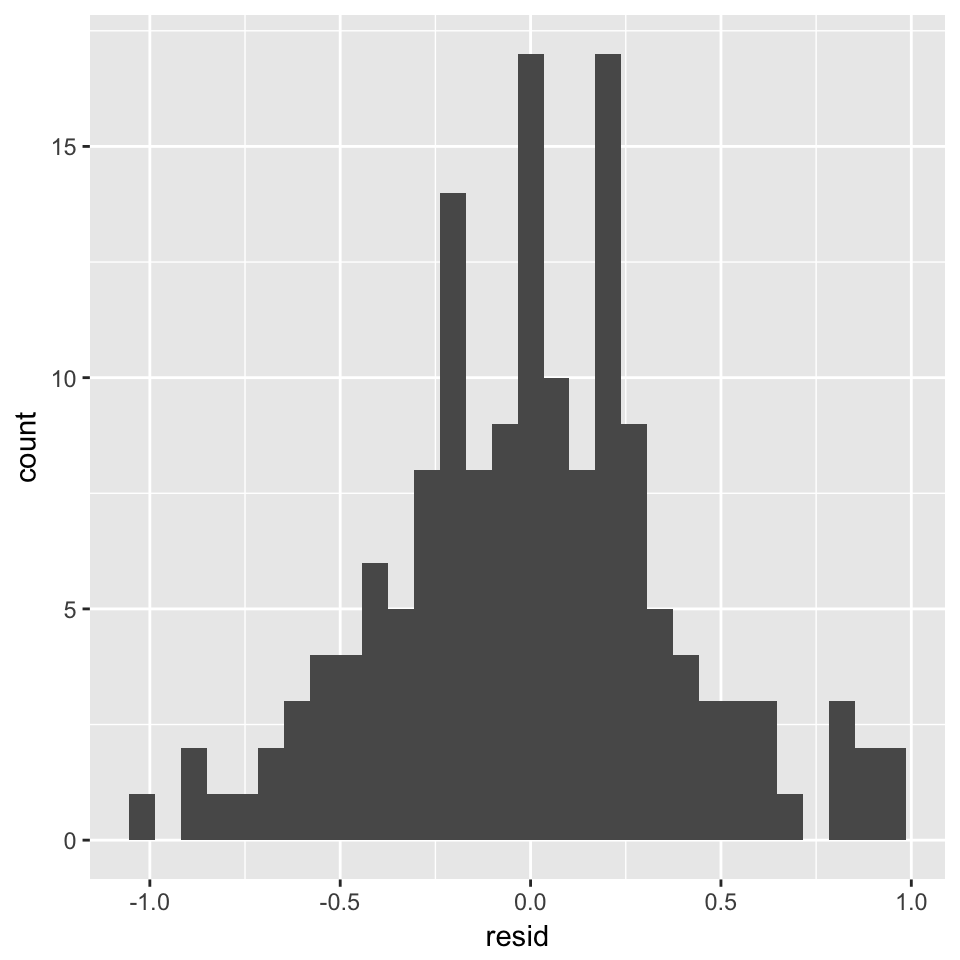

## Spatial residual analysis

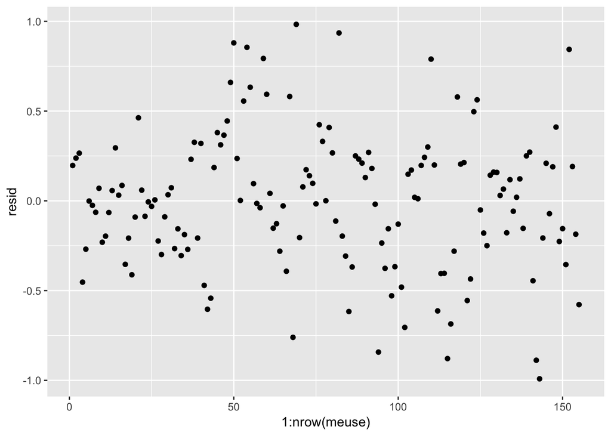

## Spatial residual analysis

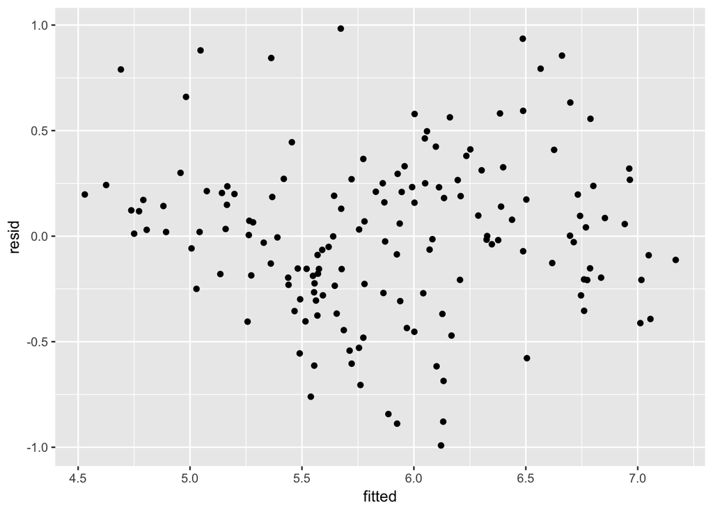

## Spatial residual analysis

The residuals look fine. There's no serial correlation or heteroskedasticity. However, are the residuals spatially independent?

```r
meuse$residuals <- fit$residuals

p <- ggplot(meuse, aes(x = x, y = y, col = residuals, size = residuals)) +
  geom_point() +
  scale_color_gradient2()
```

## Spatial residual analysis

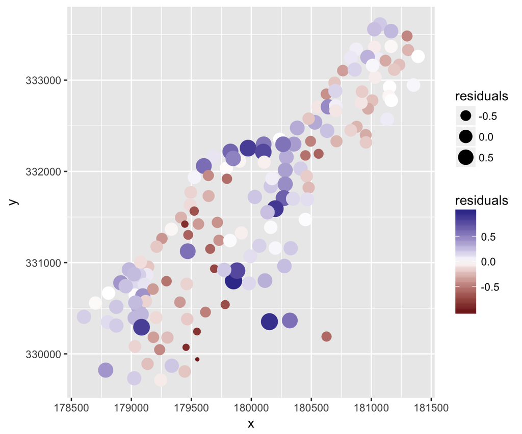

## Spatial residual analysis

Testing for spatial autocorrelation:

```r
library(spdep)

dnn <- dnearneigh(as.matrix(meuse[,c("x", "y")]), d1 = 0, d2 = 200)
neighw <- nb2listw(dnn, style = "W", zero.policy = TRUE)
moran <- moran.mc(fit$residuals, neighw, nsim = 999, zero.policy = TRUE)

moran
```

```
##
##  Monte-Carlo simulation of Moran I
##
## data:  fit$residuals
## weights: neighw
## number of simulations + 1: 1000
##
## statistic = 0.41534, observed rank = 1000, p-value = 0.001
## alternative hypothesis: greater
```

## Spatial residual analysis

Sensitivity analysis:

```r
moran_I <- c()

for (d in seq(50, 2000, 50)) {
  dnn <- dnearneigh(as.matrix(meuse[,c("x", "y")]), d1 = 0, d2 = d)
  neighw <- nb2listw(dnn, style = "W", zero.policy = TRUE)
  moran <- moran.mc(fit$residuals, neighw, nsim = 999, zero.policy = TRUE)
  moran_I <- c(moran_I, moran$statistic)
}

moran_I <- data.frame(moran = moran_I,
                      distance = seq(50, 2000, 50))

p <- ggplot(moran_I, aes(x = distance, y = moran)) +
  geom_point() +
  geom_line()
```

## Spatial residual analysis

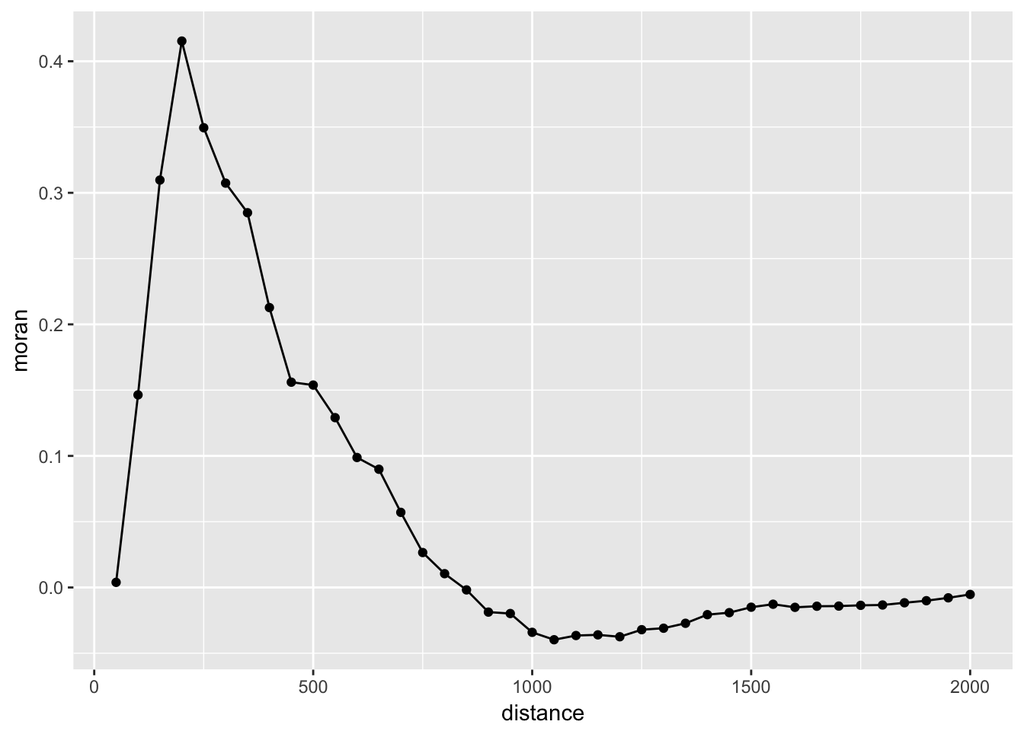

## Spatial regression models

We can use spatial lag models (or spatial simultaneous autoregressive lag model) to encounter spatial auto-correlation in the residuals. Spatial lag models incorporate an additional parameter of lagged y-values:

\(y = \rho * W * y + X\beta + e\) with \(e \sim N(0, \sigma)\)

Where \(\rho\) estimates the influence of neighboring values of y and \(W\) defines a weighted neighborhood matrix.

## Spatial regression models

Building a spatial lag model in R is easy using the `lagsarlm()` function in the `spdep` package:

```r
dnn <- dnearneigh(as.matrix(meuse[,c("x", "y")]), d1 = 0, d2 = 400)
neighw <- nb2listw(dnn, style = "W", zero.policy = TRUE)

fit_sp1 <- lagsarlm(log(zinc) ~ elev + sqrt(dist), data = meuse, listw = neighw, zero.policy = TRUE)
```

```
##
## Call:lagsarlm(formula = log(zinc) ~ elev + sqrt(dist), data = meuse,
##     listw = neighw, zero.policy = TRUE)
##
## Residuals:
##       Min        1Q    Median        3Q       Max
## -0.903645 -0.237299  0.020993  0.217945  1.063129
##
## Type: lag
## Coefficients: (asymptotic standard errors)
##              Estimate Std. Error z value  Pr(>|z|)
## (Intercept)  7.130513   0.792848  8.9935 < 2.2e-16
## elev        -0.222103   0.034373 -6.4616 1.036e-10
## sqrt(dist)  -1.690813   0.215131 -7.8595 3.775e-15
##
## Rho: 0.22252, LR test value: 3.89, p-value: 0.048576
## Asymptotic standard error: 0.10641
##     z-value: 2.0912, p-value: 0.036509
## Wald statistic: 4.3732, p-value: 0.036509
##
## Log likelihood: -67.59788 for lag model
## ML residual variance (sigma squared): 0.13944, (sigma: 0.37342)
## Number of observations: 155
## Number of parameters estimated: 5
## AIC: 145.2, (AIC for lm: 147.09)
## LM test for residual autocorrelation
## test value: 33.973, p-value: 5.5886e-09
```

## Spatial regression models

```r
meuse$residuals_sp1 <- fit_sp1$residuals

p <- ggplot(meuse, aes(x = x, y = y, col = residuals_sp1, size = residuals)) +
  geom_point() +
  scale_color_gradient2()
```

## Spatial regression models

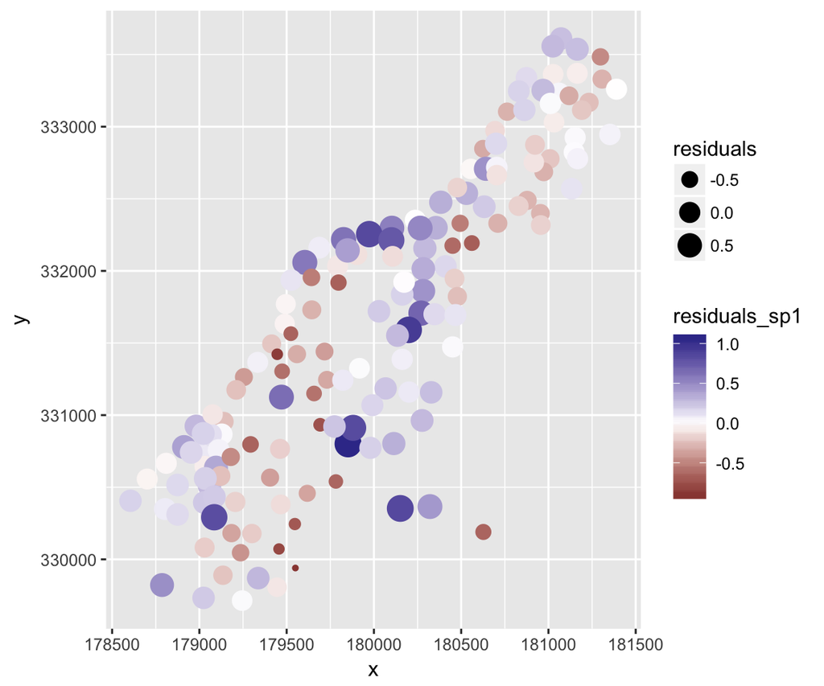

## Spatial regression models

The spatial lag model didn't account for our spatially auto-correlated residuals. Alternatively, we can use spatial error model, which incorporate an additional parameter of lagged residual values:

\(y = X\beta + u\) with \(U = \lambda * W * u + e\) and \(e ~ N(0, \sigma)\)

## Spatial regression models

Building a spatial error model in R is easy using the `errorsarlm()` function in the `spdep` package:

```r
dnn <- dnearneigh(as.matrix(meuse[,c("x", "y")]), d1 = 0, d2 = 400)
neighw <- nb2listw(dnn, style = "W", zero.policy = TRUE)

fit_sp2 <- errorsarlm(log(zinc) ~ elev + sqrt(dist), data = meuse, listw = neighw, zero.policy = TRUE)
```

```
##
## Call:errorsarlm(formula = log(zinc) ~ elev + sqrt(dist), data = meuse,
##     listw = neighw, zero.policy = TRUE)
##
## Residuals:
##      Min       1Q   Median       3Q      Max
## -0.97807 -0.19225  0.02272  0.19137  0.99993
##
## Type: error
## Coefficients: (asymptotic standard errors)
##              Estimate Std. Error  z value  Pr(>|z|)
## (Intercept)  8.874137   0.268217  33.0857 < 2.2e-16
## elev        -0.255025   0.034443  -7.4043 1.319e-13
## sqrt(dist)  -2.093863   0.199186 -10.5121 < 2.2e-16
##
## Lambda: 0.63489, LR test value: 24.476, p-value: 7.525e-07
## Asymptotic standard error: 0.099188
##     z-value: 6.4009, p-value: 1.5448e-10
## Wald statistic: 40.971, p-value: 1.5448e-10
##
## Log likelihood: -57.30497 for error model
## ML residual variance (sigma squared): 0.11698, (sigma: 0.34203)
## Number of observations: 155
## Number of parameters estimated: 5
## AIC: 124.61, (AIC for lm: 147.09)
```

## Spatial regression models

```r
meuse$residuals_sp2 <- fit_sp2$residuals

p <- ggplot(meuse, aes(x = x, y = y, col = residuals_sp2, size = residuals)) +
  geom_point() +
  scale_color_gradient2()
```

## Spatial regression models

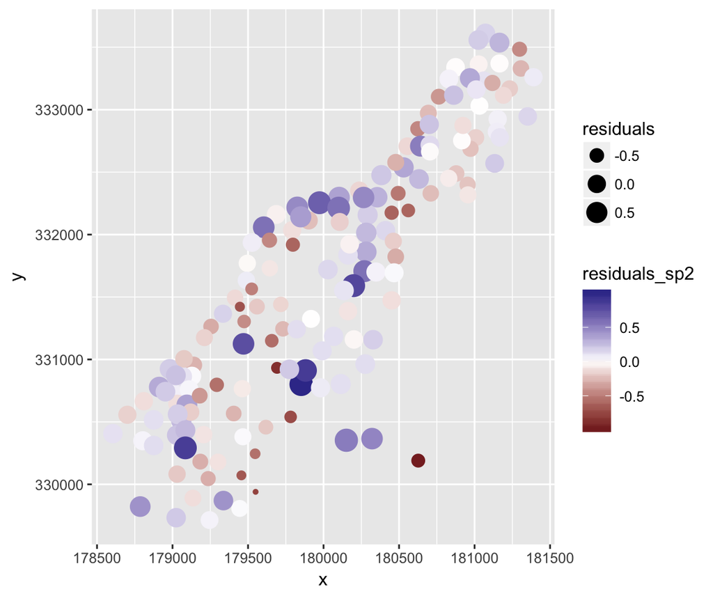

## Spatial regression models

```r
moran_I <- c()
moran_I_sp1 <- c()
moran_I_sp2 <- c()

for (d in seq(50, 2000, 50)) {
  dnn <- dnearneigh(as.matrix(meuse[,c("x", "y")]), d1 = 0, d2 = d)
  neighw <- nb2listw(dnn, style = "W", zero.policy = TRUE)

  moran <- moran.mc(fit$residuals, neighw, nsim = 999, zero.policy = TRUE)
  moran_I <- c(moran_I, moran$statistic)

  moran_sp1 <- moran.mc(fit_sp1$residuals, neighw, nsim = 999, zero.policy = TRUE)
  moran_I_sp1 <- c(moran_I_sp1, moran_sp1$statistic)

  moran_sp2 <- moran.mc(fit_sp2$residuals, neighw, nsim = 999, zero.policy = TRUE)
  moran_I_sp2 <- c(moran_I_sp2, moran_sp2$statistic)
}
```

## Spatial regression models

```r
moran_I <- data.frame(moran = moran_I,
                      moran_sp1 = moran_I_sp1,
                      moran_sp2 = moran_I_sp2,
                      distance = seq(50, 2000, 50))

p <- ggplot(moran_I) +
  geom_point(aes(x = distance, y = moran)) +
  geom_line(aes(x = distance, y = moran)) +
  geom_point(aes(x = distance, y = moran_sp1), col = "red") +
  geom_line(aes(x = distance, y = moran_sp1), col = "red") +
  geom_point(aes(x = distance, y = moran_sp2), col = "blue") +
  geom_line(aes(x = distance, y = moran_sp2), col = "blue")
```

## Spatial regression models

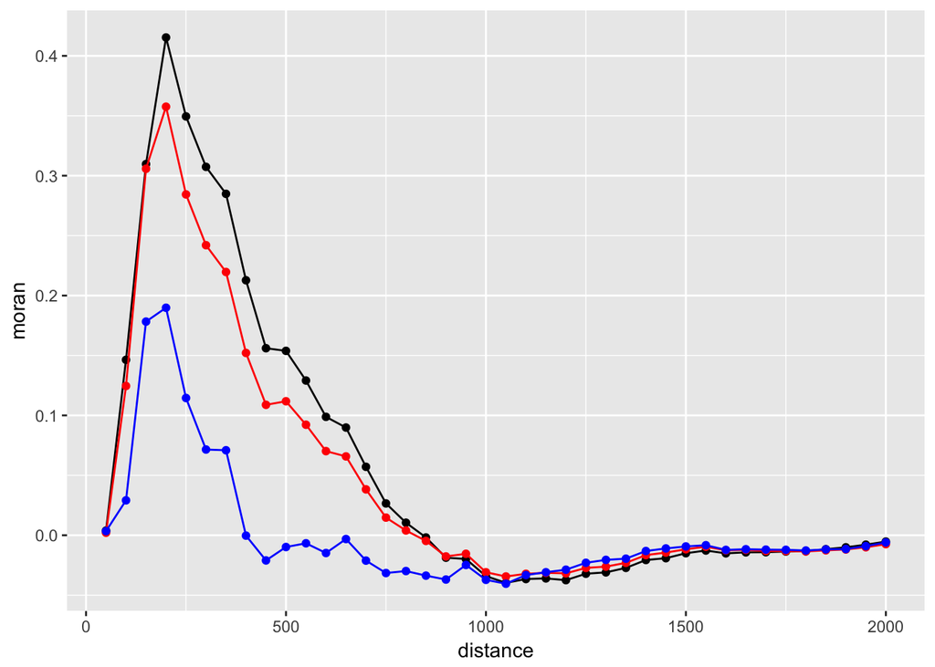

## Spatial regression models

```r
AIC(fit, fit_sp1, fit_sp2)
```

```
##         df      AIC
## fit      4 147.0857
## fit_sp1  5 145.1958
## fit_sp2  5 124.6099
```